# Assignment 3 - Nonlinear optimization

## Problem 1

Using the bisection method calculate at least one zero for
$$f(x) = -x^3+4x^2-2$$
starting for a suitable initial guess. You may want to reuse the code provided in the exercise session.

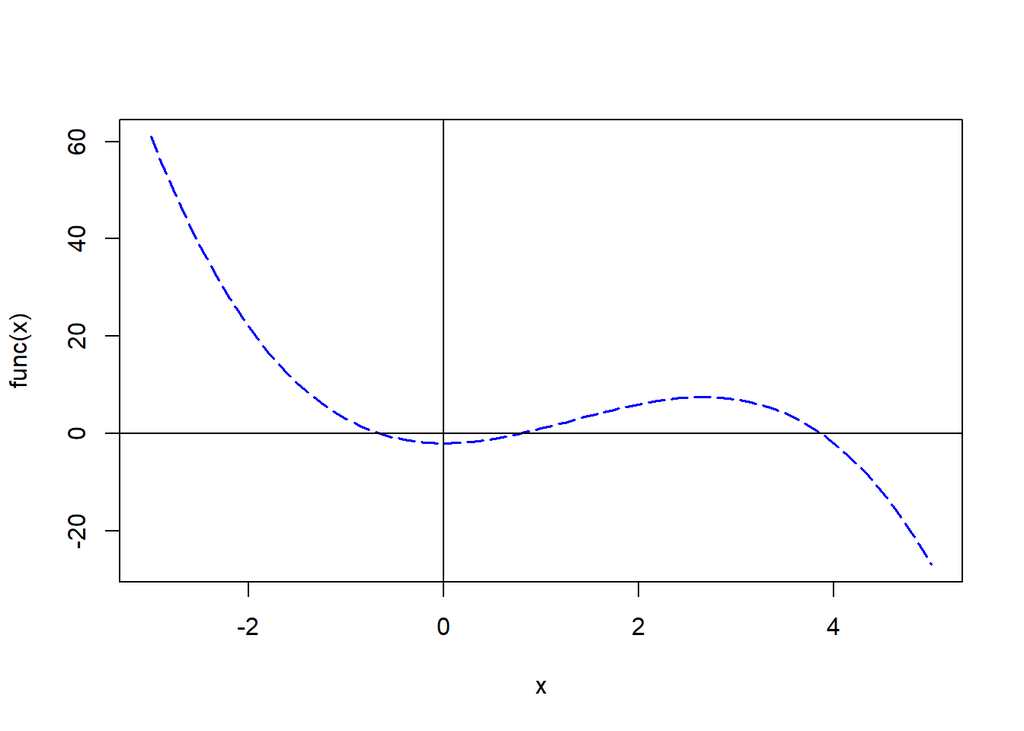

```r
library(NLRoot)

func <- function(x) {
  -x^3+4*x^2-2
}

curve(func, xlim=c(-3,5), col='blue', lwd=1.5, lty=5)
abline(h=0)
abline(v=0)
```

The roots appears to lie close to -1, 1 and 4, so we will use the interval [-1,4]

```r
BFfzero(func, -1, 4)
```

```
## [1] 1
## [1] -0.6554451
## [1] 1.775058e-05
## [1] 2
## [1] 0.7892418
## [1] -1.034969e-05
## [1] 3
## [1] 3.866199
## [1] -1.712537e-05
## [1] "finding root is successful"
```

## Problem 2

Consider the following minimization problem:
$$\min f\left(x_{1}, x_{2}\right)=2 x_{1}^{2}+x_{1} x_{2}+2\left(x_{2}-3\right)^{2}$$

1.Apply an iteration of the gradient method by performing the line search in an exact way, starting from the point
$$A=(-1,4)^{\top}$$
Report all the steps of the method, not just the result.

2.Apply an iteration of Newton’s method from point A. Verify that the point found is the minimum of function f. Report all the steps of the method, not just the result.

3.How many iterations of Newton’s method are required to optimize a quadratic function?

Rewriting the function:
$$MIN : f(x1, x2) = 2(x1)^2 + x1x2 + 2(x2)^2 − 12x2 + 18$$
Having our starting point x0 = A, we compute the gradient vector at the point x by derivating f with respect to each variable.

$$∇f(xk) = \frac{∂f(x)}{∂xi} = [4x1 + x2 ; x1 + 4x2 − 12]$$
*First iteration*

In point A the gradient takes value:
$$∇f(xk) = [0, 3]$$
Since our problem is a minimization problem, our search function will be the opposite of gradient vector, eitherway we can give alpha the sign “minus”. At the next iteration we have x1 which is equal to:
$$x1 = [−1, 4] − α_0[0, 3] = [−1; 4 − 3α_0]$$
We substitute this value in the initial function and we compute the root for which the first derivative is equal to 0.

$$f(−1; 4 − 3α_0) = 2 − 4 + 3a_0 + 2(4 − 3α_0)^2 − 12(4 − 3α_0) + 18 = 18α^2 − 9α = 36α_0 − 9α_0$$
$$36α_0 − 9α_0 = 0$$
$$α0 = \frac14$$
$$x1 = [−1;\frac{13}4]$$
The gradient in the next point can be obtained by substituting the values just found in the original gradient vector. It being equal to:
$$∇f(xk+1) = [\frac{−3}{4}, 0]$$

We now need to evaluate if the stop criteria is satisfied. It was convenient to set the stop criteria to 0.1 so that this way we need to find a value of the gradient for which the following inequality is satisfied.

$$||∇f(xk+1)|| < ε$$

$$||∇f(xk+1)|| = \sqrt{(\frac{−3}4)^2 + 0^2} = 0.75 < 0.11\ FALSE$$
The stop criteria is not respected so we must go on.

We now start from the point to which we moved and compute the next step the same way we just did. This time some calculations are omitted. Last but not least, it’s important to remind that the gradient (eitherway alpha) will retain a negative value.

$$x_2 = [−1,\frac{13}4] − α_1[\frac34, 0] = [−1 +\frac34α_1;\frac{13}4]$$

The Newton’s method lets us compute the value which nullifies the first derivative once again.

$$f(−1 +\frac34α_1;\frac{13}4) = \frac98α^2_1 −\frac{9}{16}α_1 \frac{−9}8$$

$$α_1 =1/4$$

$$x_2 = [−1 +\frac34α_1;\frac{13}4] = [\frac{−13}{16};\frac{13}4]$$

The gradient is:

$$∇f(xk+1) = [0; \frac{3}{16}]$$

Does this respect the stop criteria?

$$||∇f(xk+1)|| =\sqrt{(\frac{3}{16})^2 + 0^2} = 0.1875 < 0.1\ FALSE$$

*Third iteration*

$$f'(\frac{−13}{16};\frac{13}4− α_2 ∗\frac{13}{16}) = \frac{169}{64}α^2_2 −\frac{39}{256}$$

$$α_2 =\frac{3}{52}$$

Which lets us compute the value of the current point x3 and the deviation from the error range. Just by replacing the value of α2 in the equation.

[−0.8125, 3.203125]

$$∇f(xk+1) = [−3/64; 0]$$

$$||∇f(xk+1)|| =\sqrt{(\frac{−3}{64})^2 + 0^2} = 0.046875 < 0.1\ TRUE$$

Now we’ll see an approximation of the solution using Newton’s multivariate method. To do this we’ll need the gradient vector of the function and the inverse Hessian matrix, having still A(-1, 4)T as starting point. We found the gradient vector and the value it takes in A before.

$$∇f(xk) = \frac{∂f(x)}{∂x_i}= [4x_1 + x_2 ; x_1 + 4x_2 − 12] = [0, 3]$$
The Hessian matrix is defined from the n^2 partial derivates with respect to the n variables. The matrix and its inverse are equal to. . .

$$H(x_k) = \begin{bmatrix}4 \ 1 \\ 1 \ 4\end{bmatrix}$$

$$H(x_k)^{−1} = \begin{bmatrix}\frac{4}{15} \frac{−1}{15}\\ \frac{−1}{15} \frac{4}{15}\end{bmatrix}$$

Now everything is ready to compute xk+1

$$x_{k+1} = x_k − H(x_k)^{−1} ∇f(x_k)$$
$$x_1 = x_0 − H(x_0)^{−1}∇f(x_0)$$
$$x_1 = \begin{bmatrix}−1\\4\end{bmatrix} − \begin{bmatrix}\frac{4}{15} \frac{−1}{15} \\ \frac{−1}{15} \frac{4}{15}\end{bmatrix} \begin{bmatrix}0\\3\end{bmatrix}= \begin{bmatrix}\frac{−4}{5}\\ \frac{16}5\end{bmatrix}=\begin{bmatrix}−0.8\\3.2\end{bmatrix}$$

Having found the solutions, we expect the gradient vector in x1 to be 0 for the method to converge.

$$∇f(x_{k+1}) = [4x_1 + x_2 ; x_1 + 4x_2 − 12] = [0, 0]$$

## Problem 3

3. Use the Simulated annealing algorithm to find the global minimum of the following function.

$$f(x) = 34 e^{-\frac{1}{2}\left(\frac{x-88}{2}\right)^{2}}+(\frac{x}{10} -2\sin (\frac{x}{10}))^{2}$$

Notice that f(x) may have several local optima, thus restarting and a careful selection of the algorithm parameters may be necessary.

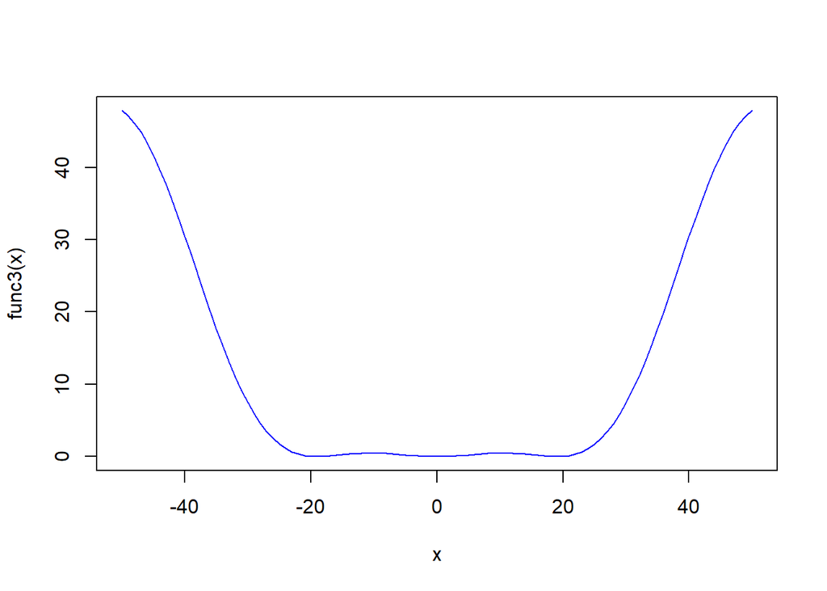

```r
func3 <- function(x){
  34*exp(-1/2*((x-88)/2)^2) + (x/10 - 2*sin(x/10))^2
}

curve(func3, xlim=c(-50,50), col='blue', lwd=1, lty=1)
```

From the plot we could say that there are global minimum near 20 and near 0.

We decide to implement the simulated annealing algorithm with the following parameters:

```r
library(ConsPlan)

f <- function(x)
{
  34*exp(-1/2*((x-88)/2)^2) + (x/10 - 2*sin(x/10))^2
}

genNewSol <- function(currentSol)
{
  rnorm(1, mean = currentSol, sd = ((30+30)/6))
}

results <- data.frame(x = rep(0, 15), value = rep(0, 15))
options(digits = 10)

for (i in 1:nrow(results))
{
  sa_opt = sann(start.seq = runif(1, min = -30, max = 30),
                fn = f,
                gr = genNewSol,
                maxit = 10000,
                REPORT = NULL,
                tmax = 5,
                temp = 1000)

  results$x[i] <- sa_opt$sequence
  results$value[i] <- sa_opt$value
}
```

```r
results
```

| x | value |
| --- | --- |
| 18.964645734032 | 2.529046917e-06 |
| 18.954754998742 | 9.450164166e-10 |
| -18.954428914460 | 7.081731779e-09 |
| -18.952623962481 | 1.442205716e-07 |
| -18.949820641718 | 7.035228748e-07 |
| 0.006212810423 | 3.859900341e-07 |
| 18.956610045279 | 7.461085395e-08 |
| -18.954875041702 | 1.227183641e-10 |
| -0.003035144508 | 9.212101618e-08 |
| 18.957181510972 | 1.345273373e-07 |

[output cut: 5 more lines]

On this part we can see the coordinates (x,y) of the points in which the optimum are located. We have a total of 3 global optima in proximity of x1 = -18.95, x2 = 0, x3 = 18.95 (because the function is simmetric), whose y value converged to 0.